# Notas Prueba 1 - CBIT241 (2024)

Horacio Samaniego

2024-05-17

## Cargar datos

```r
p1 = read.csv('~/Downloads/P1.csv',sep='\t')

kable(p1, caption = "Puntajes y nota de prueba 1 (Ecología de paisaje)",booktabs = TRUE) |>
  kable_styling("hover") |>
  scroll_box( height = "300px")
```

Puntajes y nota de prueba 1 (Ecología de paisaje)

| Nombre | Apellido | Puntos | Nota |
| --- | --- | --- | --- |
| NATALIA STEFANY | ALMAZÁN IGOR | 16.0 | 3.5 |
| PILAR MARISEL | ANDRADE CÁRDENAS | 17.5 | 3.7 |
| LÍA MAITE | BRAVO ABARCA | 24.0 | 5.1 |
| BÁRBARA SOFÍA | BRAVO URBINA | 23.0 | 4.9 |
| ROCÍO ANTONIA | BURGOS IBÁÑEZ | 24.0 | 5.1 |
| CAMILO JOAQUÍN | BUSTOS PÉREZ | 25.0 | 5.4 |
| MARTINA ANTONIA | CADAGÁN GUZMÁN | 23.5 | 5.0 |
| BARBARA ANTONIA | CARO PÉREZ | 25.0 | 5.4 |
| JAVIER ENRIQUE | CONTRERAS CUBILLOS | 24.0 | 5.1 |
| LUCAS SEBASTIÁN | CORREA ALDERETE | 26.0 | 5.6 |
| GONZALO DANIEL | DONOSO KODA | NA | 1.0 |
| JOAQUÍN RODRIGO | ESPINOZA GARCÍA | 22.0 | 4.7 |
| ALEJANDRA ISIDORA | HUERTA BANDA | 15.0 | 3.3 |
| JOSEBA ISMAEL | IRIBARREN LINEROS | 32.0 | 7.0 |
| JOSÉ TOMÁS | LUHR ARREDONDO | 25.5 | 5.5 |
| ALEN NICOLÁS | MIRANDA MELIPILLÁN | 32.0 | 7.0 |
| CONSTANZA PAZ | MUÑOZ VÁSQUEZ | 29.5 | 6.4 |
| CRISTÓBAL IGNACIO | NEGRÓN DÍAZ | 9.0 | 2.4 |
| LUCAS FRANCISCO | OYARZÚN CONTRERAS | 20.0 | 4.2 |
| PRISCILA SOLEDAD | PAREDES CÁRCAMO | 26.0 | 5.6 |
| AGUSTÍN SEBASTIÁN | PÉREZ GONZÁLEZ | 26.0 | 5.6 |
| CRISTÓBAL DANIEL | PÉREZ LÓPEZ | 30.0 | 6.5 |
| HELVETICA ANWAR | PÉREZ MONDACA | 9.0 | 2.4 |
| SOFÍA CONSTANZA | PINTO ALVEAL | 23.0 | 4.9 |
| LENNY PAOLO | SALGADO RUBINA | 29.0 | 6.3 |
| EVELYN VALENTINA PAZ | SANCHEZ GODOY | 24.5 | 5.2 |
| NICOLÁS BENJAMÍN | SEGOVIA SÁNCHEZ | 23.0 | 4.9 |
| NATHALY STEFFANY | SERÓN OJEDA | 30.0 | 6.5 |
| CRISTIAN ARNOLDO | SOTO HELLRIEGEL | 28.0 | 6.1 |
| CONSTANZA JAVIERA | TOLEDO JARA | 16.0 | 3.5 |
| JOAQUÍN ALEJANDRO | ULLOA ALMEYDA | 28.5 | 6.2 |
| LUNA MARU | VALDEAVELLANO GALILEA | 4.5 | 1.7 |
| NICOLÁS HUMBERTO | VERA LAGOS | 20.0 | 4.2 |

# ¿Cómo le fué al curso?

Aqui la tabla de frecuencia de las notas. Es una distibución de cuantas pruebas tuvieron qué nota.

```r
print(table(p1$Nota))
```

```
##
##   1 1.7 2.4 3.3 3.5 3.7 4.2 4.7 4.9   5 5.1 5.2 5.4 5.5 5.6 6.1 6.2 6.3 6.4 6.5
##   1   1   2   1   2   1   2   1   3   1   3   1   2   1   3   1   1   1   1   2
##   7
##   2
```

De los 32 que dieron la prueba, hay 2 sietes, 8 rojos. Puedes ver también, según tu nota, en que percentil estás:

```
##    Min. 1st Qu.  Median    Mean 3rd Qu.    Max.
##   1.000   4.200   5.100   4.845   5.600   7.000
```

## ¿Debo preocuparme?

- Nota 4.0 corresponde a un 60%
- Como ocurre usualmente, existen 4 grupos. El “*promedio*”, los que “*salvaron*”, los “*sobresalientes*” y los que están “*super mal*”, en ese orden.
  1. Te sacaste entre un 5 y un 6

     Estás en el promedio
  2. Estás cerca o debajo del 4

     Debes ponerle color, para entender los conceptos que se hablan en clases y ojalá mejorar tu rendimiento. Usa el Discord, pregunta y participa en clases. Creo que enecesitas un pequeño empujón para quedar contento con tu rendimiento
  3. Estas cerca, o sobre el 6. Eres de los que le ha puesto mas color, y entusiasmo. Participa en Discord para contagiar con tu entusiamo a tus compañeros. Sigue aportando y preguntando!
  4. Estás muy por debajo del 4. Debes preocuparte. Acercate al profe para ver que estas haciendo mal. Si es falta de etusiasmo, hay poco que pueden hacer por ti, recupéralo. Si lo intentaste, acercate y participa en la clase, siéntate mas adelante, interrumpe para exigir que te expliquen. Debes preocpuarte, si. Es muy probable que debas cambiar radicalmente tu aproximación al ramo y seguro que puedes apoyarte en el profe y un par de amigos.

## Distribución de notas

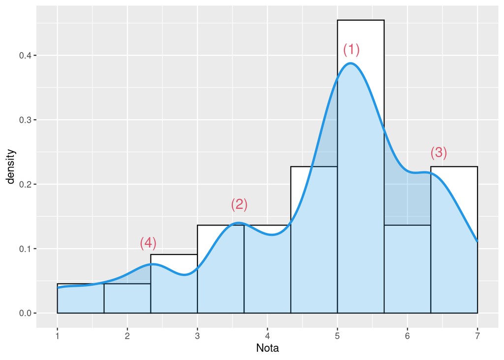

```r
ggplot(p1, aes(x = Nota)) +
  geom_histogram(aes(y = ..density..), bins = 10, colour = 1, fill = "white") +
  geom_density(lwd = 1.1, linetype = 1,colour = 4,fill = 4, alpha = 0.25,bw=0.35) +
  annotate("text", x=6.45, y=.25, label="(3)",color=2,cex=5) +
  annotate("text", x=5.2, y=.41, label="(1)",color=2,cex=5) +
  annotate("text", x=3.6, y=.17, label="(2)",color=2,cex=5) +
  annotate("text", x=2.3, y=.11, label="(4)",color=2,cex=5) +
  scale_x_continuous(breaks=c(1.0:7.0))
```